# BL_Revision

```r
anova(adol.alpha.model, adol.beta.model)
```

```
## refitting model(s) with ML (instead of REML)
```

```
## Data: adolescents
## Models:
## adol.alpha.model: MP_PC ~ 1 + Alpha * PPVT * age + (1 | age)
## adol.beta.model: MP_PC ~ 1 + Beta * PPVT * age + (1 | age)
##                  Df      AIC    BIC logLik deviance  Chisq Chi Df
## adol.alpha.model 10  -6.5783 7.0947 13.289  -26.578
## adol.beta.model  10 -11.4433 2.2296 15.722  -31.443 4.8651      0
##                  Pr(>Chisq)
## adol.alpha.model
## adol.beta.model   < 2.2e-16 ***
## ---
## Signif. codes:  0 '***' 0.001 '**' 0.01 '*' 0.05 '.' 0.1 ' ' 1
```

```r
summary(adol.alpha.model)
```

```
## Linear mixed model fit by REML. t-tests use Satterthwaite's method [
## lmerModLmerTest]
## Formula: MP_PC ~ 1 + Alpha * PPVT * age + (1 | age)
##    Data: adolescents
##
## REML criterion at convergence: 31.7
##
## Scaled residuals:
##      Min       1Q   Median       3Q      Max
## -2.45246 -0.35394  0.04873  0.38743  1.51115
##
## Random effects:
##  Groups   Name        Variance Std.Dev.
##  age      (Intercept) 0.01177  0.1085
##  Residual             0.02825  0.1681
## Number of obs: 29, groups:  age, 3
##
## Fixed effects:
##                 Estimate Std. Error        df t value Pr(>|t|)
## (Intercept)    -0.126933   2.357879  9.727123  -0.054    0.958
## Alpha          -0.294831   1.329840 20.427782  -0.222    0.827
## PPVT            0.103315   0.078180 20.132072   1.322    0.201
## age             0.055805   0.169917  9.946039   0.328    0.749
## Alpha:PPVT      0.026996   0.047694 20.469242   0.566    0.578
## Alpha:age       0.019735   0.095461 20.433686   0.207    0.838
## PPVT:age       -0.006804   0.005425 20.165801  -1.254    0.224
## Alpha:PPVT:age -0.001713   0.003352 20.505678  -0.511    0.615
##
## Correlation of Fixed Effects:
##             (Intr) Alpha  PPVT   age    Al:PPVT Alph:g PPVT:g
## Alpha        0.717
## PPVT        -0.763 -0.672
## age         -0.999 -0.720  0.751
## Alpha:PPVT  -0.634 -0.884  0.778  0.627
## Alpha:age   -0.720 -0.999  0.664  0.725  0.874
## PPVT:age     0.777  0.686 -0.999 -0.766 -0.780  -0.679
## Alph:PPVT:g  0.637  0.890 -0.768 -0.632 -0.999  -0.882  0.772
```

```r
summary(adol.beta.model)
```

```
## Linear mixed model fit by REML. t-tests use Satterthwaite's method [
## lmerModLmerTest]
## Formula: MP_PC ~ 1 + Beta * PPVT * age + (1 | age)
##    Data: adolescents
##
## REML criterion at convergence: 22.6
##
## Scaled residuals:
##      Min       1Q   Median       3Q      Max
## -2.09176 -0.33569  0.05618  0.48068  2.00480
##
## Random effects:
##  Groups   Name        Variance Std.Dev.
##  age      (Intercept) 0.00956  0.09778
##  Residual             0.02398  0.15484
## Number of obs: 29, groups:  age, 3
##
## Fixed effects:
##                Estimate Std. Error        df t value Pr(>|t|)
## (Intercept)    2.670359   1.816799  5.964611   1.470   0.1923
## Beta          -5.097760   2.385034 20.448169  -2.137   0.0448 *
## PPVT          -0.034796   0.049782 20.324040  -0.699   0.4925
## age           -0.138389   0.130462  6.054197  -1.061   0.3293
## Beta:PPVT      0.199335   0.085608 20.293087   2.328   0.0303 *
## Beta:age       0.348724   0.170748 20.497940   2.042   0.0542 .
## PPVT:age       0.002549   0.003525 20.365676   0.723   0.4779
## Beta:PPVT:age -0.013509   0.006022 20.324618  -2.243   0.0362 *
## ---
## Signif. codes:  0 '***' 0.001 '**' 0.01 '*' 0.05 '.' 0.1 ' ' 1
##
## Correlation of Fixed Effects:
##             (Intr) Beta   PPVT   age    Bt:PPVT Beta:g PPVT:g
## Beta        -0.582
## PPVT        -0.758  0.599
## age         -0.999  0.585  0.755
## Beta:PPVT    0.476 -0.895 -0.571 -0.477
## Beta:age     0.589 -0.998 -0.602 -0.592  0.887
## PPVT:age     0.762 -0.604 -0.999 -0.760  0.572   0.608
## Beta:PPVT:g -0.485  0.900  0.576  0.486 -0.999  -0.894 -0.578
```

```r
summary(adol.theta.model)
```

```
## Linear mixed model fit by REML. t-tests use Satterthwaite's method [
## lmerModLmerTest]
## Formula: MP_PC ~ 1 + Theta * PPVT * age + (1 | age)
##    Data: adolescents
##
## REML criterion at convergence: 24.2
##
## Scaled residuals:
##     Min      1Q  Median      3Q     Max
## -2.5596 -0.1106  0.1446  0.5042  1.3086
##
## Random effects:
##  Groups   Name        Variance Std.Dev.
##  age      (Intercept) 0.009382 0.09686
##  Residual             0.028912 0.17004
## Number of obs: 29, groups:  age, 3
##
## Fixed effects:
##                 Estimate Std. Error        df t value Pr(>|t|)
## (Intercept)     2.007052   2.014625  8.211757   0.996    0.348
## Theta          -2.611331   3.375911 20.742669  -0.774    0.448
## PPVT           -0.019759   0.057585 20.031407  -0.343    0.735
## age            -0.085566   0.140282  7.664530  -0.610    0.560
## Theta:PPVT      0.151140   0.127832 20.330161   1.182    0.251
## Theta:age       0.174089   0.238962 20.774279   0.729    0.474
## PPVT:age        0.001363   0.003969 20.024728   0.344    0.735
## Theta:PPVT:age -0.010461   0.009183 20.331856  -1.139    0.268
##
## Correlation of Fixed Effects:
##             (Intr) Theta  PPVT   age    Th:PPVT Thet:g PPVT:g
## Theta       -0.556
## PPVT        -0.798  0.566
## age         -0.999  0.545  0.789
## Theta:PPVT   0.365 -0.831 -0.464 -0.359
## Theta:age    0.542 -0.999 -0.551 -0.533  0.834
## PPVT:age     0.793 -0.559 -0.998 -0.786  0.469   0.546
## Thet:PPVT:g -0.345  0.816  0.445  0.340 -0.999  -0.820 -0.451
```

```r
summary(adol.gamma.model)
```

```
## Linear mixed model fit by REML. t-tests use Satterthwaite's method [
## lmerModLmerTest]
## Formula: MP_PC ~ 1 + Theta * PPVT * age + (1 | age)
##    Data: adolescents
##
## REML criterion at convergence: 24.2
##
## Scaled residuals:
##     Min      1Q  Median      3Q     Max
## -2.5596 -0.1106  0.1446  0.5042  1.3086
##
## Random effects:
##  Groups   Name        Variance Std.Dev.
##  age      (Intercept) 0.009382 0.09686
##  Residual             0.028912 0.17004
## Number of obs: 29, groups:  age, 3
##
## Fixed effects:
##                 Estimate Std. Error        df t value Pr(>|t|)
## (Intercept)     2.007052   2.014625  8.211757   0.996    0.348
## Theta          -2.611331   3.375911 20.742669  -0.774    0.448
## PPVT           -0.019759   0.057585 20.031407  -0.343    0.735
## age            -0.085566   0.140282  7.664530  -0.610    0.560
## Theta:PPVT      0.151140   0.127832 20.330161   1.182    0.251
## Theta:age       0.174089   0.238962 20.774279   0.729    0.474
## PPVT:age        0.001363   0.003969 20.024728   0.344    0.735
## Theta:PPVT:age -0.010461   0.009183 20.331856  -1.139    0.268
##
## Correlation of Fixed Effects:
##             (Intr) Theta  PPVT   age    Th:PPVT Thet:g PPVT:g
## Theta       -0.556
## PPVT        -0.798  0.566
## age         -0.999  0.545  0.789
## Theta:PPVT   0.365 -0.831 -0.464 -0.359
## Theta:age    0.542 -0.999 -0.551 -0.533  0.834
## PPVT:age     0.793 -0.559 -0.998 -0.786  0.469   0.546
## Thet:PPVT:g -0.345  0.816  0.445  0.340 -0.999  -0.820 -0.451
```

## Working Memory and Word Learning

```r
alpha.model <- lmer(MP_PC ~ 1 + Alpha*DigSpa*age + (1|age), data = children)
```

```
## singular fit
```

```r
beta.model <- lmer(MP_PC ~ 1 + Beta*DigSpa*age + (1|age), data = children)
```

```
## singular fit
```

```r
theta.model <- lmer(MP_PC ~ 1 + Theta*DigSpa*age + (1|age), data = children)
```

```
## singular fit
```

```r
AIC(alpha.model,beta.model,theta.model)
```

```
##             df      AIC
## alpha.model 10 40.92513
## beta.model  10 39.00599
## theta.model 10 32.00982
```

```r
anova(alpha.model, beta.model)
```

```
## refitting model(s) with ML (instead of REML)
```

```
## Data: children
## Models:
## alpha.model: MP_PC ~ 1 + Alpha * DigSpa * age + (1 | age)
## beta.model: MP_PC ~ 1 + Beta * DigSpa * age + (1 | age)
##             Df    AIC    BIC logLik deviance Chisq Chi Df Pr(>Chisq)
## alpha.model 10 -14.97 4.9194 17.485   -34.97
## beta.model  10 -10.93 8.9598 15.465   -30.93     0      0          1
```

```r
summary(alpha.model)
```

```
## Linear mixed model fit by REML. t-tests use Satterthwaite's method [
## lmerModLmerTest]
## Formula: MP_PC ~ 1 + Alpha * DigSpa * age + (1 | age)
##    Data: children
##
## REML criterion at convergence: 20.9
##
## Scaled residuals:
##     Min      1Q  Median      3Q     Max
## -2.1907 -0.4891  0.1073  0.6788  1.6853
##
## Random effects:
##  Groups   Name        Variance Std.Dev.
##  age      (Intercept) 0.00000  0.0000
##  Residual             0.03597  0.1897
## Number of obs: 54, groups:  age, 3
##
## Fixed effects:
##                   Estimate Std. Error        df t value Pr(>|t|)
## (Intercept)      -2.569580   1.440710 46.000000  -1.784   0.0811 .
## Alpha            -1.168368   0.669135 46.000000  -1.746   0.0875 .
## DigSpa            0.196592   0.135120 46.000000   1.455   0.1525
## age               0.349095   0.159579 46.000000   2.188   0.0338 *
## Alpha:DigSpa      0.090703   0.062378 46.000000   1.454   0.1527
## Alpha:age         0.127623   0.072965 46.000000   1.749   0.0869 .
## DigSpa:age       -0.022071   0.014833 46.000000  -1.488   0.1436
## Alpha:DigSpa:age -0.010147   0.006826 46.000000  -1.487   0.1440
## ---
## Signif. codes:  0 '***' 0.001 '**' 0.01 '*' 0.05 '.' 0.1 ' ' 1
##
## Correlation of Fixed Effects:
##             (Intr) Alpha  DigSpa age    Alp:DS Alph:g DgSp:g
## Alpha        0.754
## DigSpa      -0.971 -0.735
## age         -0.998 -0.750  0.966
## Alpha:DigSp -0.728 -0.950  0.746  0.724
## Alpha:age   -0.757 -0.997  0.737  0.756  0.949
## DigSpa:age   0.971  0.734 -0.998 -0.970 -0.745 -0.739
## Alph:DgSp:g  0.728  0.945 -0.745 -0.726 -0.997 -0.949  0.747
## convergence code: 0
## singular fit
```

```r
summary(beta.model)
```

```
## Linear mixed model fit by REML. t-tests use Satterthwaite's method [
## lmerModLmerTest]
## Formula: MP_PC ~ 1 + Beta * DigSpa * age + (1 | age)
##    Data: children
##
## REML criterion at convergence: 19
##
## Scaled residuals:
##      Min       1Q   Median       3Q      Max
## -2.14257 -0.58526  0.04064  0.72466  1.76039
##
## Random effects:
##  Groups   Name        Variance Std.Dev.
##  age      (Intercept) 0.00000  0.0000
##  Residual             0.03876  0.1969
## Number of obs: 54, groups:  age, 3
##
## Fixed effects:
##                  Estimate Std. Error        df t value Pr(>|t|)
## (Intercept)     -0.113568   1.480130 46.000000  -0.077    0.939
## Beta            -1.016060   1.118032 46.000000  -0.909    0.368
## DigSpa          -0.020833   0.133173 46.000000  -0.156    0.876
## age              0.065630   0.167280 46.000000   0.392    0.697
## Beta:DigSpa      0.112415   0.108749 46.000000   1.034    0.307
## Beta:age         0.129172   0.134664 46.000000   0.959    0.342
## DigSpa:age       0.003122   0.014943 46.000000   0.209    0.835
## Beta:DigSpa:age -0.014017   0.012903 46.000000  -1.086    0.283
##
## Correlation of Fixed Effects:
##             (Intr) Beta   DigSpa age    Bt:DgS Beta:g DgSp:g
## Beta        -0.734
## DigSpa      -0.970  0.705
## age         -0.998  0.753  0.966
## Beta:DigSpa  0.599 -0.878 -0.623 -0.618
## Beta:age     0.725 -0.998 -0.695 -0.746  0.874
## DigSpa:age   0.971 -0.726 -0.998 -0.971  0.643  0.719
## Beta:DgSp:g -0.607  0.893  0.628  0.628 -0.997 -0.892 -0.651
## convergence code: 0
## singular fit
```

```r
summary(theta.model)
```

```
## Linear mixed model fit by REML. t-tests use Satterthwaite's method [
## lmerModLmerTest]
## Formula: MP_PC ~ 1 + Theta * DigSpa * age + (1 | age)
##    Data: children
##
## REML criterion at convergence: 12
##
## Scaled residuals:
##     Min      1Q  Median      3Q     Max
## -2.1005 -0.6720  0.1450  0.7219  2.1800
##
## Random effects:
##  Groups   Name        Variance  Std.Dev.
##  age      (Intercept) 5.976e-15 7.731e-08
##  Residual             3.541e-02 1.882e-01
## Number of obs: 54, groups:  age, 3
##
## Fixed effects:
##                   Estimate Std. Error        df t value Pr(>|t|)
## (Intercept)      -0.204016   1.271855 46.000000  -0.160    0.873
## Theta            -1.001280   1.850511 46.000000  -0.541    0.591
## DigSpa            0.058756   0.119967 46.000000   0.490    0.627
## age               0.082946   0.137820 46.000000   0.602    0.550
## Theta:DigSpa     -0.062895   0.180251 46.000000  -0.349    0.729
## Theta:age         0.119722   0.203413 46.000000   0.589    0.559
## DigSpa:age       -0.005755   0.013054 46.000000  -0.441    0.661
## Theta:DigSpa:age  0.004973   0.019756 46.000000   0.252    0.802
##
## Correlation of Fixed Effects:
##             (Intr) Theta  DigSpa age    Tht:DS Thet:g DgSp:g
## Theta       -0.670
## DigSpa      -0.934  0.644
## age         -0.996  0.661  0.931
## Theta:DigSp  0.583 -0.924 -0.662 -0.578
## Theta:age    0.666 -0.999 -0.640 -0.659  0.923
## DigSpa:age   0.931 -0.638 -0.996 -0.934  0.658  0.637
## Thet:DgSp:g -0.586  0.929  0.662  0.583 -0.998 -0.930 -0.661
## convergence code: 0
## singular fit
```

```r
adol.alpha.model <- lmer(MP_PC ~ 1 + Alpha*DigSpa*age + (1|age), data = adolescents)
adol.beta.model <- lmer(MP_PC ~ 1 + Beta*DigSpa*age + (1|age), data = adolescents)
adol.theta.model <- lmer(MP_PC ~ 1 + Theta*DigSpa*age + (1|age), data = adolescents)
```

```
## singular fit
```

```r
adol.gamma.model <- lmer(MP_PC ~ 1 + Theta*DigSpa*age + (1|age), data = adolescents)
```

```
## singular fit
```

```r
AIC(adol.alpha.model,adol.beta.model,adol.theta.model,adol.gamma.model)
```

```
##                  df      AIC
## adol.alpha.model 10 37.64860
## adol.beta.model  10 29.82360
## adol.theta.model 10 30.99588
## adol.gamma.model 10 30.99588
```

```r
anova(adol.alpha.model, adol.beta.model)
```

```
## refitting model(s) with ML (instead of REML)
```

```
## Data: adolescents
## Models:
## adol.alpha.model: MP_PC ~ 1 + Alpha * DigSpa * age + (1 | age)
## adol.beta.model: MP_PC ~ 1 + Beta * DigSpa * age + (1 | age)
##                  Df     AIC     BIC logLik deviance  Chisq Chi Df
## adol.alpha.model 10 -13.538  0.1353 16.769  -33.538
## adol.beta.model  10 -17.233 -3.5597 18.616  -37.233 3.6951      0
##                  Pr(>Chisq)
## adol.alpha.model
## adol.beta.model   < 2.2e-16 ***
## ---
## Signif. codes:  0 '***' 0.001 '**' 0.01 '*' 0.05 '.' 0.1 ' ' 1
```

```r
summary(adol.alpha.model)
```

```
## Linear mixed model fit by REML. t-tests use Satterthwaite's method [
## lmerModLmerTest]
## Formula: MP_PC ~ 1 + Alpha * DigSpa * age + (1 | age)
##    Data: adolescents
##
## REML criterion at convergence: 17.6
##
## Scaled residuals:
##     Min      1Q  Median      3Q     Max
## -3.2302 -0.2651  0.0133  0.5427  1.1046
##
## Random effects:
##  Groups   Name        Variance Std.Dev.
##  age      (Intercept) 0.001893 0.04351
##  Residual             0.024624 0.15692
## Number of obs: 29, groups:  age, 3
##
## Fixed effects:
##                   Estimate Std. Error        df t value Pr(>|t|)
## (Intercept)      -0.234182   3.630708 20.933456  -0.065    0.949
## Alpha             0.016223   2.860936 20.148844   0.006    0.996
## DigSpa            0.151566   0.298030 20.075033   0.509    0.617
## age               0.073829   0.260424 20.929374   0.283    0.780
## Alpha:DigSpa     -0.012822   0.233771 20.096457  -0.055    0.957
## Alpha:age        -0.006385   0.204856 20.169099  -0.031    0.975
## DigSpa:age       -0.011011   0.021452 20.074689  -0.513    0.613
## Alpha:DigSpa:age  0.001602   0.016769 20.109241   0.096    0.925
##
## Correlation of Fixed Effects:
##             (Intr) Alpha  DigSpa age    Alp:DS Alph:g DgSp:g
## Alpha        0.915
## DigSpa      -0.965 -0.889
## age         -0.999 -0.913  0.965
## Alpha:DigSp -0.900 -0.984  0.904  0.899
## Alpha:age   -0.915 -1.000  0.890  0.914  0.984
## DigSpa:age   0.963  0.886 -0.999 -0.965 -0.902 -0.888
## Alph:DgSp:g  0.899  0.983 -0.904 -0.899 -1.000 -0.983  0.903
```

```r
summary(adol.beta.model)
```

```
## Linear mixed model fit by REML. t-tests use Satterthwaite's method [
## lmerModLmerTest]
## Formula: MP_PC ~ 1 + Beta * DigSpa * age + (1 | age)
##    Data: adolescents
##
## REML criterion at convergence: 9.8
##
## Scaled residuals:
##     Min      1Q  Median      3Q     Max
## -2.5039 -0.3095  0.1311  0.5778  1.2497
##
## Random effects:
##  Groups   Name        Variance Std.Dev.
##  age      (Intercept) 0.003621 0.06018
##  Residual             0.021074 0.14517
## Number of obs: 29, groups:  age, 3
##
## Fixed effects:
##                 Estimate Std. Error       df t value Pr(>|t|)
## (Intercept)     -1.75840    1.69612 12.72643  -1.037   0.3192
## Beta             1.99759    2.76413 20.99273   0.723   0.4778
## DigSpa           0.34278    0.14496 20.38282   2.365   0.0281 *
## age              0.18596    0.12012 12.58940   1.548   0.1464
## Beta:DigSpa     -0.34059    0.24942 20.97203  -1.365   0.1866
## Beta:age        -0.12809    0.20006 20.98905  -0.640   0.5289
## DigSpa:age      -0.02528    0.01032 20.34070  -2.449   0.0235 *
## Beta:DigSpa:age  0.02281    0.01799 20.94444   1.268   0.2188
## ---
## Signif. codes:  0 '***' 0.001 '**' 0.01 '*' 0.05 '.' 0.1 ' ' 1
##
## Correlation of Fixed Effects:
##             (Intr) Beta   DigSpa age    Bt:DgS Beta:g DgSp:g
## Beta        -0.366
## DigSpa      -0.860  0.374
## age         -0.999  0.354  0.859
## Beta:DigSpa  0.351 -0.935 -0.435 -0.340
## Beta:age     0.346 -0.999 -0.354 -0.334  0.932
## DigSpa:age   0.855 -0.361 -0.999 -0.855  0.426  0.342
## Beta:DgSp:g -0.333  0.936  0.419  0.323 -0.998 -0.936 -0.411
```

```r
summary(adol.theta.model)
```

```
## Linear mixed model fit by REML. t-tests use Satterthwaite's method [
## lmerModLmerTest]
## Formula: MP_PC ~ 1 + Theta * DigSpa * age + (1 | age)
##    Data: adolescents
##
## REML criterion at convergence: 11
##
## Scaled residuals:
##     Min      1Q  Median      3Q     Max
## -3.2282 -0.1983  0.1380  0.4920  1.0806
##
## Random effects:
##  Groups   Name        Variance Std.Dev.
##  age      (Intercept) 0.00000  0.0000
##  Residual             0.02515  0.1586
## Number of obs: 29, groups:  age, 3
##
## Fixed effects:
##                   Estimate Std. Error        df t value Pr(>|t|)
## (Intercept)      -0.216199   1.486595 21.000000  -0.145    0.886
## Theta            -2.357805   3.983070 21.000000  -0.592    0.560
## DigSpa            0.179939   0.152914 21.000000   1.177    0.252
## age               0.085249   0.106589 21.000000   0.800    0.433
## Theta:DigSpa      0.099066   0.377871 21.000000   0.262    0.796
## Theta:age         0.158416   0.288441 21.000000   0.549    0.589
## DigSpa:age       -0.014768   0.011041 21.000000  -1.338    0.195
## Theta:DigSpa:age -0.005458   0.027511 21.000000  -0.198    0.845
##
## Correlation of Fixed Effects:
##             (Intr) Theta  DigSpa age    Tht:DS Thet:g DgSp:g
## Theta       -0.160
## DigSpa      -0.884  0.211
## age         -0.999  0.152  0.884
## Theta:DigSp  0.215 -0.917 -0.382 -0.211
## Theta:age    0.153 -0.999 -0.207 -0.145  0.918
## DigSpa:age   0.879 -0.206 -0.998 -0.882  0.382  0.203
## Thet:DgSp:g -0.210  0.913  0.379  0.206 -0.999 -0.915 -0.380
## convergence code: 0
## singular fit
```

```r
summary(adol.gamma.model)
```

```
## Linear mixed model fit by REML. t-tests use Satterthwaite's method [
## lmerModLmerTest]
## Formula: MP_PC ~ 1 + Theta * DigSpa * age + (1 | age)
##    Data: adolescents
##
## REML criterion at convergence: 11
##
## Scaled residuals:
##     Min      1Q  Median      3Q     Max
## -3.2282 -0.1983  0.1380  0.4920  1.0806
##
## Random effects:
##  Groups   Name        Variance Std.Dev.
##  age      (Intercept) 0.00000  0.0000
##  Residual             0.02515  0.1586
## Number of obs: 29, groups:  age, 3
##
## Fixed effects:
##                   Estimate Std. Error        df t value Pr(>|t|)
## (Intercept)      -0.216199   1.486595 21.000000  -0.145    0.886
## Theta            -2.357805   3.983070 21.000000  -0.592    0.560
## DigSpa            0.179939   0.152914 21.000000   1.177    0.252
## age               0.085249   0.106589 21.000000   0.800    0.433
## Theta:DigSpa      0.099066   0.377871 21.000000   0.262    0.796
## Theta:age         0.158416   0.288441 21.000000   0.549    0.589
## DigSpa:age       -0.014768   0.011041 21.000000  -1.338    0.195
## Theta:DigSpa:age -0.005458   0.027511 21.000000  -0.198    0.845
##
## Correlation of Fixed Effects:
##             (Intr) Theta  DigSpa age    Tht:DS Thet:g DgSp:g
## Theta       -0.160
## DigSpa      -0.884  0.211
## age         -0.999  0.152  0.884
## Theta:DigSp  0.215 -0.917 -0.382 -0.211
## Theta:age    0.153 -0.999 -0.207 -0.145  0.918
## DigSpa:age   0.879 -0.206 -0.998 -0.882  0.382  0.203
## Thet:DgSp:g -0.210  0.913  0.379  0.206 -0.999 -0.915 -0.380
## convergence code: 0
## singular fit
```

### Old analysis below this line:

### Theta LMEM:Compared two models, one with Reading, one without. The model with Reading is a better fit (Chi-square = 7.308523 (df= 1 ), p = 0.006862832), with theta moderately predicting vocabulary (p = 0.08)

```r
fm1 <- lmer(PPVT.Raw.Score ~ 1 + Theta_F + Thet_LP + Thet_RP + age + (1|age), data = df_overall)
fm2 <- lmer(PPVT.Raw.Score ~ 1 + Theta_F + Thet_LP + Thet_RP + GortCo + age + (1|age), data = df_overall)

AIC(fm1,fm2)
```

```
##     df      AIC
## fm1  7 701.3523
## fm2  8 696.0438
```

```r
dev0 <- -2*logLik(fm1) # deviance simpler model
dev1 <- -2*logLik(fm2) # deviance complex model
devdiff <- as.numeric(dev0-dev1) # difference in deviances
dfdiff <- attr(dev1,"df")-attr(dev0,"df") # difference in params (using dfs)
cat('Chi-square =', devdiff, '(df=', dfdiff,'), p =',
  pchisq(devdiff,dfdiff,lower.tail=FALSE))
```

```
## Chi-square = 7.308523 (df= 1 ), p = 0.006862832
```

```r
summary(fm2)
```

```
## Linear mixed model fit by REML. t-tests use Satterthwaite's method [
## lmerModLmerTest]
## Formula:
## PPVT.Raw.Score ~ 1 + Theta_F + Thet_LP + Thet_RP + GortCo + age +
##     (1 | age)
##    Data: df_overall
##
## REML criterion at convergence: 680
##
## Scaled residuals:
##      Min       1Q   Median       3Q      Max
## -2.66953 -0.68584  0.07679  0.65392  2.16822
##
## Random effects:
##  Groups   Name        Variance Std.Dev.
##  age      (Intercept)  49.05    7.003
##  Residual             266.74   16.332
## Number of obs: 83, groups:  age, 6
##
## Fixed effects:
##             Estimate Std. Error       df t value Pr(>|t|)
## (Intercept)   5.0026    16.3962   4.2633   0.305  0.77461
## Theta_F     -10.8131     6.1061  75.0081  -1.771  0.08065 .
## Thet_LP       1.0277     4.5442  74.6083   0.226  0.82170
## Thet_RP       2.0813     4.5739  73.6268   0.455  0.65042
## GortCo       -0.9117     0.3210  72.8653  -2.840  0.00584 **
## age           5.5093     1.3613   3.9273   4.047  0.01609 *
## ---
## Signif. codes:  0 '***' 0.001 '**' 0.01 '*' 0.05 '.' 0.1 ' ' 1
##
## Correlation of Fixed Effects:
##         (Intr) Thet_F Tht_LP Tht_RP GortCo
## Theta_F -0.058
## Thet_LP  0.001 -0.468
## Thet_RP -0.181 -0.419 -0.299
## GortCo  -0.177 -0.078  0.071  0.019
## age     -0.953  0.072 -0.060  0.134 -0.005
```

### Plot Theta Effect: Moderate effect of Theta on Vocabulary (note: this graph does NOT account for other effects that are factored out in the LMER)

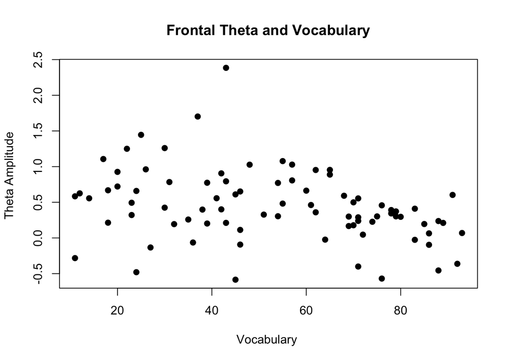

```r
plot(df_overall$PPVT.Raw.Score, df_overall$Theta_F, main="Frontal Theta and Vocabulary",
   xlab="Vocabulary ", ylab="Theta Amplitude ", pch=19)
```

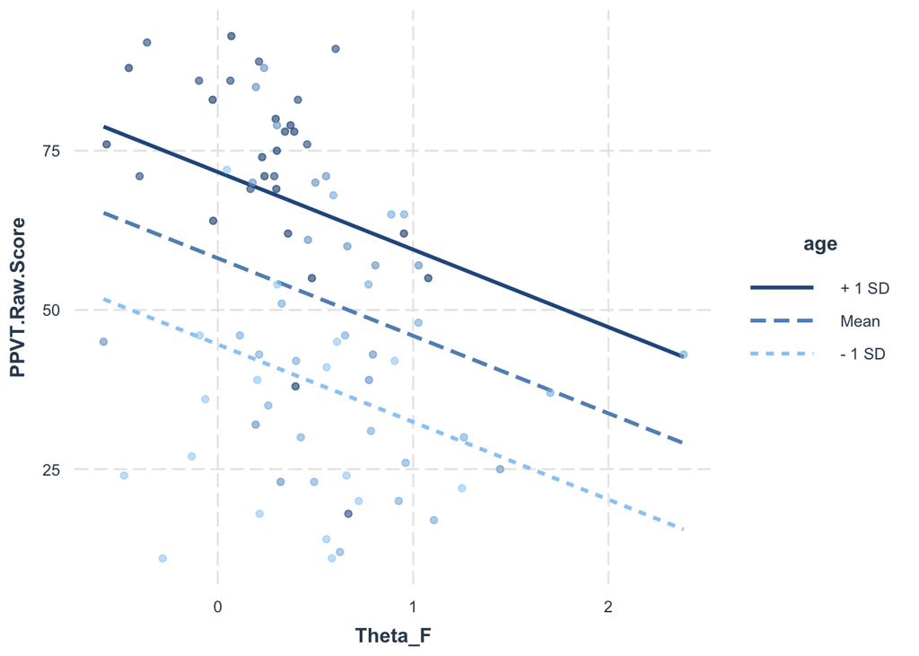

```r
interact_plot(fm1, pred = Theta_F, modx = age, plot.points = TRUE)
```

### Investigating interaction between Theta and Vocabulary on Word Learning

```r
fm1 <- lmer(MAve_A ~ 1 + Theta_F*PPVT.Raw.Score + age + (1|age), data = df_overall)
```

```
## singular fit
```

```r
fm2 <- lmer(MAve_A ~ 1 + Thet_RP*PPVT.Raw.Score + age + (1|age), data = df_overall)
```

```
## singular fit
```

```r
fm3 <- lmer(MAve_A ~ 1 + Thet_LP*PPVT.Raw.Score + age + (1|age), data = df_overall)
```

```
## singular fit
```

```r
AIC(fm1,fm2,fm3)
```

```
##     df        AIC
## fm1  7 -0.6047001
## fm2  7  0.7814056
## fm3  7  0.2350089
```

```r
anova(fm1, fm2)
```

```
## refitting model(s) with ML (instead of REML)
```

```
## Data: df_overall
## Models:
## fm1: MAve_A ~ 1 + Theta_F * PPVT.Raw.Score + age + (1 | age)
## fm2: MAve_A ~ 1 + Thet_RP * PPVT.Raw.Score + age + (1 | age)
##     Df    AIC     BIC logLik deviance Chisq Chi Df Pr(>Chisq)
## fm1  7 -41.41 -24.478 27.705   -55.41
## fm2  7 -40.73 -23.798 27.365   -54.73     0      0          1
```

```r
summary(fm1)
```

```
## Linear mixed model fit by REML. t-tests use Satterthwaite's method [
## lmerModLmerTest]
## Formula: MAve_A ~ 1 + Theta_F * PPVT.Raw.Score + age + (1 | age)
##    Data: df_overall
##
## REML criterion at convergence: -14.6
##
## Scaled residuals:
##     Min      1Q  Median      3Q     Max
## -3.4059 -0.3332  0.2498  0.5927  1.6480
##
## Random effects:
##  Groups   Name        Variance  Std.Dev.
##  age      (Intercept) 5.453e-18 2.335e-09
##  Residual             3.196e-02 1.788e-01
## Number of obs: 83, groups:  age, 6
##
## Fixed effects:
##                         Estimate Std. Error        df t value Pr(>|t|)
## (Intercept)             0.717744   0.100493 78.000000   7.142 4.22e-10 ***
## Theta_F                -0.093016   0.102130 78.000000  -0.911    0.365
## PPVT.Raw.Score          0.002168   0.001373 78.000000   1.579    0.118
## age                    -0.003624   0.010939 78.000000  -0.331    0.741
## Theta_F:PPVT.Raw.Score  0.001654   0.002046 78.000000   0.808    0.421
## ---
## Signif. codes:  0 '***' 0.001 '**' 0.01 '*' 0.05 '.' 0.1 ' ' 1
##
## Correlation of Fixed Effects:
##             (Intr) Thet_F PPVT.R age
## Theta_F     -0.345
## PPVT.Rw.Scr -0.046  0.587
## age         -0.732 -0.143 -0.614
## T_F:PPVT.R.  0.195 -0.911 -0.571  0.196
## convergence code: 0
## singular fit
```

```r
summary(fm2)
```

```
## Linear mixed model fit by REML. t-tests use Satterthwaite's method [
## lmerModLmerTest]
## Formula: MAve_A ~ 1 + Thet_RP * PPVT.Raw.Score + age + (1 | age)
##    Data: df_overall
##
## REML criterion at convergence: -13.2
##
## Scaled residuals:
##     Min      1Q  Median      3Q     Max
## -3.4101 -0.3467  0.2516  0.5566  1.6357
##
## Random effects:
##  Groups   Name        Variance  Std.Dev.
##  age      (Intercept) 1.408e-17 3.752e-09
##  Residual             3.222e-02 1.795e-01
## Number of obs: 83, groups:  age, 6
##
## Fixed effects:
##                          Estimate Std. Error         df t value Pr(>|t|)
## (Intercept)             0.6957172  0.1131114 78.0000000   6.151 3.09e-08
## Thet_RP                -0.0307724  0.0939661 78.0000000  -0.327   0.7442
## PPVT.Raw.Score          0.0025121  0.0014743 78.0000000   1.704   0.0924
## age                    -0.0042320  0.0110136 78.0000000  -0.384   0.7018
## Thet_RP:PPVT.Raw.Score  0.0007069  0.0017264 78.0000000   0.409   0.6833
##
## (Intercept)            ***
## Thet_RP
## PPVT.Raw.Score         .
## age
## Thet_RP:PPVT.Raw.Score
## ---
## Signif. codes:  0 '***' 0.001 '**' 0.01 '*' 0.05 '.' 0.1 ' ' 1
##
## Correlation of Fixed Effects:
##             (Intr) Tht_RP PPVT.R age
## Thet_RP     -0.538
## PPVT.Rw.Scr -0.178  0.631
## age         -0.714 -0.004 -0.526
## T_RP:PPVT.R  0.398 -0.929 -0.656  0.087
## convergence code: 0
## singular fit
```

```r
summary(fm3)
```

```
## Linear mixed model fit by REML. t-tests use Satterthwaite's method [
## lmerModLmerTest]
## Formula: MAve_A ~ 1 + Thet_LP * PPVT.Raw.Score + age + (1 | age)
##    Data: df_overall
##
## REML criterion at convergence: -13.8
##
## Scaled residuals:
##     Min      1Q  Median      3Q     Max
## -3.5439 -0.3819  0.2660  0.5837  1.4485
##
## Random effects:
##  Groups   Name        Variance Std.Dev.
##  age      (Intercept) 0.00000  0.0000
##  Residual             0.03192  0.1787
## Number of obs: 83, groups:  age, 6
##
## Fixed effects:
##                          Estimate Std. Error         df t value Pr(>|t|)
## (Intercept)             0.7194821  0.1034134 78.0000000   6.957  9.5e-10
## Thet_LP                -0.0378601  0.0825231 78.0000000  -0.459   0.6477
## PPVT.Raw.Score          0.0027440  0.0013893 78.0000000   1.975   0.0518
## age                    -0.0056364  0.0107052 78.0000000  -0.527   0.6000
## Thet_LP:PPVT.Raw.Score  0.0001286  0.0016258 78.0000000   0.079   0.9372
##
## (Intercept)            ***
## Thet_LP
## PPVT.Raw.Score         .
## age
## Thet_LP:PPVT.Raw.Score
## ---
## Signif. codes:  0 '***' 0.001 '**' 0.01 '*' 0.05 '.' 0.1 ' ' 1
##
## Correlation of Fixed Effects:
##             (Intr) Tht_LP PPVT.R age
## Thet_LP     -0.478
## PPVT.Rw.Scr -0.126  0.579
## age         -0.744  0.010 -0.527
## T_LP:PPVT.R  0.383 -0.916 -0.604  0.018
## convergence code: 0
## singular fit
```

```r
fm1 <- lmer(MAve_A ~ 1 + Theta_F*age + (1|age), data = df_overall)
```

```
## singular fit
```

```r
fm2 <- lmer(MAve_A ~ 1 + Thet_RP*age + (1|age), data = df_overall)
```

```
## singular fit
```

```r
fm3 <- lmer(MAve_A ~ 1 + Thet_LP*age + (1|age), data = df_overall)
```

```
## singular fit
```

```r
AIC(fm1,fm2,fm3)
```

```
##     df       AIC
## fm1  6 -12.57712
## fm2  6 -12.27899
## fm3  6 -13.24390
```

```r
anova(fm1, fm2)
```

```
## refitting model(s) with ML (instead of REML)
```

```
## Data: df_overall
## Models:
## fm1: MAve_A ~ 1 + Theta_F * age + (1 | age)
## fm2: MAve_A ~ 1 + Thet_RP * age + (1 | age)
##     Df     AIC     BIC logLik deviance  Chisq Chi Df Pr(>Chisq)
## fm1  6 -36.816 -22.303 24.408  -48.816
## fm2  6 -37.178 -22.665 24.589  -49.178 0.3627      0  < 2.2e-16 ***
## ---
## Signif. codes:  0 '***' 0.001 '**' 0.01 '*' 0.05 '.' 0.1 ' ' 1
```

```r
summary(fm1)
```

```
## Linear mixed model fit by REML. t-tests use Satterthwaite's method [
## lmerModLmerTest]
## Formula: MAve_A ~ 1 + Theta_F * age + (1 | age)
##    Data: df_overall
##
## REML criterion at convergence: -24.6
##
## Scaled residuals:
##     Min      1Q  Median      3Q     Max
## -3.5511 -0.3575  0.2104  0.6576  1.3133
##
## Random effects:
##  Groups   Name        Variance  Std.Dev.
##  age      (Intercept) 5.969e-17 7.726e-09
##  Residual             3.416e-02 1.848e-01
## Number of obs: 83, groups:  age, 6
##
## Fixed effects:
##             Estimate Std. Error       df t value Pr(>|t|)
## (Intercept)  0.71863    0.11870 79.00000   6.054 4.49e-08 ***
## Theta_F     -0.15890    0.20632 79.00000  -0.770    0.443
## age          0.00790    0.01036 79.00000   0.763    0.448
## Theta_F:age  0.01198    0.02011 79.00000   0.596    0.553
## ---
## Signif. codes:  0 '***' 0.001 '**' 0.01 '*' 0.05 '.' 0.1 ' ' 1
##
## Correlation of Fixed Effects:
##             (Intr) Thet_F age
## Theta_F     -0.584
## age         -0.973  0.583
## Theta_F:age  0.517 -0.978 -0.547
## convergence code: 0
## singular fit
```

```r
summary(fm2)
```

```
## Linear mixed model fit by REML. t-tests use Satterthwaite's method [
## lmerModLmerTest]
## Formula: MAve_A ~ 1 + Thet_RP * age + (1 | age)
##    Data: df_overall
##
## REML criterion at convergence: -24.3
##
## Scaled residuals:
##     Min      1Q  Median      3Q     Max
## -3.4793 -0.2779  0.1971  0.6305  1.3963
##
## Random effects:
##  Groups   Name        Variance  Std.Dev.
##  age      (Intercept) 1.486e-17 3.855e-09
##  Residual             3.401e-02 1.844e-01
## Number of obs: 83, groups:  age, 6
##
## Fixed effects:
##              Estimate Std. Error        df t value Pr(>|t|)
## (Intercept)  0.745907   0.133907 79.000000   5.570 3.39e-07 ***
## Thet_RP     -0.219163   0.179505 79.000000  -1.221    0.226
## age          0.004001   0.011581 79.000000   0.345    0.731
## Thet_RP:age  0.021542   0.017456 79.000000   1.234    0.221
## ---
## Signif. codes:  0 '***' 0.001 '**' 0.01 '*' 0.05 '.' 0.1 ' ' 1
##
## Correlation of Fixed Effects:
##             (Intr) Tht_RP age
## Thet_RP     -0.680
## age         -0.975  0.686
## Thet_RP:age  0.613 -0.980 -0.649
## convergence code: 0
## singular fit
```

```r
summary(fm3)
```

```
## Linear mixed model fit by REML. t-tests use Satterthwaite's method [
## lmerModLmerTest]
## Formula: MAve_A ~ 1 + Thet_LP * age + (1 | age)
##    Data: df_overall
##
## REML criterion at convergence: -25.2
##
## Scaled residuals:
##     Min      1Q  Median      3Q     Max
## -3.7247 -0.3854  0.2106  0.6426  1.4866
##
## Random effects:
##  Groups   Name        Variance  Std.Dev.
##  age      (Intercept) 1.305e-17 3.613e-09
##  Residual             3.350e-02 1.830e-01
## Number of obs: 83, groups:  age, 6
##
## Fixed effects:
##              Estimate Std. Error        df t value Pr(>|t|)
## (Intercept)  0.772473   0.122818 79.000000   6.290 1.64e-08 ***
## Thet_LP     -0.231517   0.163675 79.000000  -1.414    0.161
## age          0.003037   0.011157 79.000000   0.272    0.786
## Thet_LP:age  0.019370   0.016082 79.000000   1.204    0.232
## ---
## Signif. codes:  0 '***' 0.001 '**' 0.01 '*' 0.05 '.' 0.1 ' ' 1
##
## Correlation of Fixed Effects:
##             (Intr) Tht_LP age
## Thet_LP     -0.660
## age         -0.971  0.673
## Thet_LP:age  0.615 -0.978 -0.663
## convergence code: 0
## singular fit
```

### Omnibus LMEM: No significant patterns, best fit model is model 1

```r
fm1 <- lmer(GortCo ~ 1 + Alp_3m1 + Beta_Glob_2on_S3 + GamGl_3m1 + age + (1|age), data = df_overall)
```

```
## singular fit
```

```r
fm2 <- lmer(GortCo ~ 1 + Alp_3m1 + Beta_Glob_2on_S3 + GamGl_3m1 + PPVT.Raw.Score + age + (1|age), data = df_overall)
```

```
## singular fit
```

```r
AIC(fm1,fm2)
```

```
##     df      AIC
## fm1  7 531.5183
## fm2  8 531.3521
```

```r
dev0 <- -2*logLik(fm1) # deviance simpler model
dev1 <- -2*logLik(fm2) # deviance complex model
devdiff <- as.numeric(dev0-dev1) # difference in deviances
dfdiff <- attr(dev1,"df")-attr(dev0,"df") # difference in params (using dfs)
cat('Chi-square =', devdiff, '(df=', dfdiff,'), p =',
  pchisq(devdiff,dfdiff,lower.tail=FALSE))
```

```
## Chi-square = 2.166211 (df= 1 ), p = 0.1410734
```

```r
summary(fm1)
```

```
## Linear mixed model fit by REML. t-tests use Satterthwaite's method [
## lmerModLmerTest]
## Formula: GortCo ~ 1 + Alp_3m1 + Beta_Glob_2on_S3 + GamGl_3m1 + age + (1 |
##     age)
##    Data: df_overall
##
## REML criterion at convergence: 517.5
##
## Scaled residuals:
##     Min      1Q  Median      3Q     Max
## -1.5273 -0.9022 -0.1917  1.0000  1.4475
##
## Random effects:
##  Groups   Name        Variance  Std.Dev.
##  age      (Intercept) 1.474e-14 1.214e-07
##  Residual             3.276e+01 5.724e+00
## Number of obs: 83, groups:  age, 6
##
## Fixed effects:
##                  Estimate Std. Error       df t value Pr(>|t|)
## (Intercept)       8.13590    2.88364 78.00000   2.821  0.00606 **
## Alp_3m1          -0.21703    0.42339 78.00000  -0.513  0.60967
## Beta_Glob_2on_S3  1.59710    1.33991 78.00000   1.192  0.23690
## GamGl_3m1        -0.06578    0.62907 78.00000  -0.105  0.91699
## age               0.04871    0.26449 78.00000   0.184  0.85435
## ---
## Signif. codes:  0 '***' 0.001 '**' 0.01 '*' 0.05 '.' 0.1 ' ' 1
##
## Correlation of Fixed Effects:
##             (Intr) Alp_31 B_G_2_ GmG_31
## Alp_3m1      0.022
## Bt_Glb_2_S3 -0.150 -0.525
## GamGl_3m1    0.014  0.197 -0.622
## age         -0.958  0.139  0.072 -0.063
## convergence code: 0
## singular fit
```

### Word Learning LMEMs: Alpha interacts with reading comprehension to predict WL ability (p = 0.0338), there is also a main effect of alpha (p = 0.0141). Beta also predicts WL ability (p = 0.0249). Gamma does not predict WL ability. ** All when controlling for age.

```r
alpha.model <- lmer(MAve_A ~ 1 + Alp_3m1*GortCo + age + (1|age), data = df_overall)
```

```
## singular fit
```

```r
beta.model <- lmer(MAve_A ~ 1 + Beta_Glob_2on_S3*GortCo + age + (1|age), data = df_overall)
```

```
## singular fit
```

```r
gamma.model <- lmer(MAve_A ~ 1 + GamGl_3m1*GortCo + age + (1|age), data = df_overall)
```

```
## singular fit
```

```r
AIC(alpha.model,beta.model,gamma.model)
```

```
##             df        AIC
## alpha.model  7  0.9765855
## beta.model   7 -1.8735767
## gamma.model  7  4.0795417
```

```r
anova(alpha.model, beta.model)
```

```
## refitting model(s) with ML (instead of REML)
```

```
## Data: df_overall
## Models:
## alpha.model: MAve_A ~ 1 + Alp_3m1 * GortCo + age + (1 | age)
## beta.model: MAve_A ~ 1 + Beta_Glob_2on_S3 * GortCo + age + (1 | age)
##             Df     AIC     BIC logLik deviance Chisq Chi Df Pr(>Chisq)
## alpha.model  7 -40.126 -23.194 27.063  -54.126
## beta.model   7 -39.245 -22.313 26.623  -53.245     0      0          1
```

```r
summary(alpha.model)
```

```
## Linear mixed model fit by REML. t-tests use Satterthwaite's method [
## lmerModLmerTest]
## Formula: MAve_A ~ 1 + Alp_3m1 * GortCo + age + (1 | age)
##    Data: df_overall
##
## REML criterion at convergence: -13
##
## Scaled residuals:
##     Min      1Q  Median      3Q     Max
## -3.7053 -0.3742  0.2382  0.6505  1.3249
##
## Random effects:
##  Groups   Name        Variance Std.Dev.
##  age      (Intercept) 0.00000  0.0000
##  Residual             0.03246  0.1802
## Number of obs: 83, groups:  age, 6
##
## Fixed effects:
##                 Estimate Std. Error        df t value Pr(>|t|)
## (Intercept)     0.584645   0.098319 78.000000   5.946 7.31e-08 ***
## Alp_3m1        -0.049093   0.019560 78.000000  -2.510   0.0141 *
## GortCo          0.003961   0.003770 78.000000   1.050   0.2967
## age             0.014531   0.008442 78.000000   1.721   0.0892 .
## Alp_3m1:GortCo  0.004465   0.002066 78.000000   2.161   0.0338 *
## ---
## Signif. codes:  0 '***' 0.001 '**' 0.01 '*' 0.05 '.' 0.1 ' ' 1
##
## Correlation of Fixed Effects:
##             (Intr) Alp_31 GortCo age
## Alp_3m1      0.184
## GortCo      -0.395 -0.314
## age         -0.910 -0.033  0.053
## Alp_3m1:GrC -0.273 -0.822  0.360  0.182
## convergence code: 0
## singular fit
```

```r
summary(beta.model)
```

```
## Linear mixed model fit by REML. t-tests use Satterthwaite's method [
## lmerModLmerTest]
## Formula: MAve_A ~ 1 + Beta_Glob_2on_S3 * GortCo + age + (1 | age)
##    Data: df_overall
##
## REML criterion at convergence: -15.9
##
## Scaled residuals:
##     Min      1Q  Median      3Q     Max
## -3.7867 -0.2669  0.2066  0.6665  1.3179
##
## Random effects:
##  Groups   Name        Variance  Std.Dev.
##  age      (Intercept) 1.053e-17 3.245e-09
##  Residual             3.280e-02 1.811e-01
## Number of obs: 83, groups:  age, 6
##
## Fixed effects:
##                           Estimate Std. Error         df t value Pr(>|t|)
## (Intercept)              0.6562740  0.0957807 78.0000000   6.852 1.51e-09
## Beta_Glob_2on_S3        -0.1155983  0.0505392 78.0000000  -2.287   0.0249
## GortCo                  -0.0008472  0.0039278 78.0000000  -0.216   0.8298
## age                      0.0130214  0.0083169 78.0000000   1.566   0.1215
## Beta_Glob_2on_S3:GortCo  0.0083223  0.0051107 78.0000000   1.628   0.1075
##
## (Intercept)             ***
## Beta_Glob_2on_S3        *
## GortCo
## age
## Beta_Glob_2on_S3:GortCo
## ---
## Signif. codes:  0 '***' 0.001 '**' 0.01 '*' 0.05 '.' 0.1 ' ' 1
##
## Correlation of Fixed Effects:
##             (Intr) Bt_G_2_S3 GortCo age
## Bt_Glb_2_S3 -0.080
## GortCo      -0.278  0.261
## age         -0.912 -0.016    -0.076
## B_G_2_S3:GC  0.000 -0.824    -0.413  0.121
## convergence code: 0
## singular fit
```

```r
summary(gamma.model)
```

```
## Linear mixed model fit by REML. t-tests use Satterthwaite's method [
## lmerModLmerTest]
## Formula: MAve_A ~ 1 + GamGl_3m1 * GortCo + age + (1 | age)
##    Data: df_overall
##
## REML criterion at convergence: -9.9
##
## Scaled residuals:
##     Min      1Q  Median      3Q     Max
## -3.3464 -0.4434  0.1782  0.7104  1.3826
##
## Random effects:
##  Groups   Name        Variance Std.Dev.
##  age      (Intercept) 0.00000  0.0000
##  Residual             0.03439  0.1855
## Number of obs: 83, groups:  age, 6
##
## Fixed effects:
##                   Estimate Std. Error        df t value Pr(>|t|)
## (Intercept)       0.644206   0.097458 78.000000   6.610 4.31e-09 ***
## GamGl_3m1        -0.008728   0.031943 78.000000  -0.273    0.785
## GortCo            0.002060   0.004197 78.000000   0.491    0.625
## age               0.012580   0.008557 78.000000   1.470    0.146
## GamGl_3m1:GortCo -0.001153   0.003149 78.000000  -0.366    0.715
## ---
## Signif. codes:  0 '***' 0.001 '**' 0.01 '*' 0.05 '.' 0.1 ' ' 1
##
## Correlation of Fixed Effects:
##             (Intr) GmG_31 GortCo age
## GamGl_3m1   -0.012
## GortCo      -0.265  0.394
## age         -0.900 -0.176 -0.113
## GmGl_3m1:GC -0.031 -0.870 -0.500  0.213
## convergence code: 0
## singular fit
```

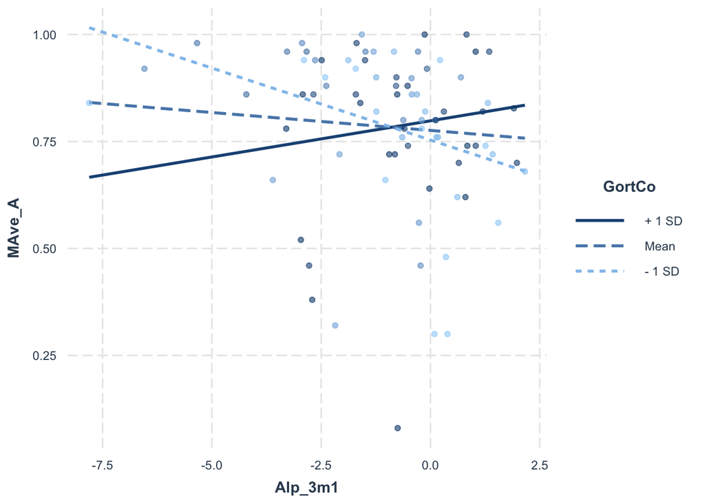

```r
interact_plot(alpha.model, pred = Alp_3m1, modx = GortCo, plot.points = TRUE)
```

### LMEM of Alpha, Beta or Gamma individually predicting Reading Comprehension. No significant results.

```r
fm1 <- lmer(GortCo ~ 1 + Alp_3m1 + age + (1|age), data = df_overall)
```

```
## singular fit
```

```r
fm2 <- lmer(GortCo ~ 1 + Beta_Glob_2on_S3 + age + (1|age), data = df_overall)
```

```
## singular fit
```

```r
fm3 <- lmer(GortCo ~ 1 + GamGl_3m1 + age + (1|age), data = df_overall)
```

```
## singular fit
```

```r
AIC(fm1,fm2,fm3)
```

```
##     df      AIC
## fm1  5 532.4454
## fm2  5 528.7521
## fm3  5 531.1742
```

```r
anova(fm1, fm2)
```

```
## refitting model(s) with ML (instead of REML)
```

```
## Data: df_overall
## Models:
## fm1: GortCo ~ 1 + Alp_3m1 + age + (1 | age)
## fm2: GortCo ~ 1 + Beta_Glob_2on_S3 + age + (1 | age)
##     Df    AIC    BIC  logLik deviance  Chisq Chi Df Pr(>Chisq)
## fm1  5 532.19 544.28 -261.09   522.19
## fm2  5 530.28 542.37 -260.14   520.28 1.9081      0  < 2.2e-16 ***
## ---
## Signif. codes:  0 '***' 0.001 '**' 0.01 '*' 0.05 '.' 0.1 ' ' 1
```

```r
summary(fm1)
```

```
## Linear mixed model fit by REML. t-tests use Satterthwaite's method [
## lmerModLmerTest]
## Formula: GortCo ~ 1 + Alp_3m1 + age + (1 | age)
##    Data: df_overall
##
## REML criterion at convergence: 522.4
##
## Scaled residuals:
##     Min      1Q  Median      3Q     Max
## -1.2745 -1.0650 -0.2202  1.0234  1.4228
##
## Random effects:
##  Groups   Name        Variance Std.Dev.
##  age      (Intercept)  0.0     0.000
##  Residual             32.8     5.727
## Number of obs: 83, groups:  age, 6
##
## Fixed effects:
##             Estimate Std. Error       df t value Pr(>|t|)
## (Intercept)  8.88784    2.83765 80.00000   3.132  0.00242 **
## Alp_3m1      0.10498    0.35362 80.00000   0.297  0.76734
## age          0.03099    0.26387 80.00000   0.117  0.90682
## ---
## Signif. codes:  0 '***' 0.001 '**' 0.01 '*' 0.05 '.' 0.1 ' ' 1
##
## Correlation of Fixed Effects:
##         (Intr) Alp_31
## Alp_3m1 -0.089
## age     -0.968  0.207
## convergence code: 0
## singular fit
```

```r
summary(fm2)
```

```
## Linear mixed model fit by REML. t-tests use Satterthwaite's method [
## lmerModLmerTest]
## Formula: GortCo ~ 1 + Beta_Glob_2on_S3 + age + (1 | age)
##    Data: df_overall
##
## REML criterion at convergence: 518.8
##
## Scaled residuals:
##     Min      1Q  Median      3Q     Max
## -1.5360 -0.9435 -0.2218  1.0082  1.4176
##
## Random effects:
##  Groups   Name        Variance Std.Dev.
##  age      (Intercept)  0.00    0.000
##  Residual             32.05    5.661
## Number of obs: 83, groups:  age, 6
##
## Fixed effects:
##                  Estimate Std. Error       df t value Pr(>|t|)
## (Intercept)       8.16847    2.85133 80.00000   2.865  0.00533 **
## Beta_Glob_2on_S3  1.23389    0.88346 80.00000   1.397  0.16638
## age               0.06743    0.25796 80.00000   0.261  0.79444
## ---
## Signif. codes:  0 '***' 0.001 '**' 0.01 '*' 0.05 '.' 0.1 ' ' 1
##
## Correlation of Fixed Effects:
##             (Intr) B_G_2_
## Bt_Glb_2_S3 -0.200
## age         -0.974  0.146
## convergence code: 0
## singular fit
```

```r
summary(fm3)
```

```
## Linear mixed model fit by REML. t-tests use Satterthwaite's method [
## lmerModLmerTest]
## Formula: GortCo ~ 1 + GamGl_3m1 + age + (1 | age)
##    Data: df_overall
##
## REML criterion at convergence: 521.2
##
## Scaled residuals:
##     Min      1Q  Median      3Q     Max
## -1.3313 -0.9638 -0.2065  1.0283  1.3762
##
## Random effects:
##  Groups   Name        Variance Std.Dev.
##  age      (Intercept)  0.00    0.000
##  Residual             32.53    5.704
## Number of obs: 83, groups:  age, 6
##
## Fixed effects:
##             Estimate Std. Error       df t value Pr(>|t|)
## (Intercept)  8.67662    2.83458 80.00000   3.061    0.003 **
## GamGl_3m1    0.41349    0.48138 80.00000   0.859    0.393
## age          0.01873    0.25713 80.00000   0.073    0.942
## ---
## Signif. codes:  0 '***' 0.001 '**' 0.01 '*' 0.05 '.' 0.1 ' ' 1
##
## Correlation of Fixed Effects:
##           (Intr) GmG_31
## GamGl_3m1 -0.118
## age       -0.970  0.018
## convergence code: 0
## singular fit
```

### LMEM with Working memory interactions

```r
alpha.model <- lmer(MAve_A ~ 1 + Alp_3m1*DigSpa + age + (1|age), data = df_overall)
```

```
## singular fit
```

```r
beta.model <- lmer(MAve_A ~ 1 + Beta_Glob_2on_S3*DigSpa + age + (1|age), data = df_overall)
```

```
## singular fit
```

```r
gamma.model <- lmer(MAve_A ~ 1 + GamGl_3m1*DigSpa + age + (1|age), data = df_overall)
```

```
## singular fit
```

```r
AIC(alpha.model,beta.model,gamma.model)
```

```
##             df       AIC
## alpha.model  7  2.312364
## beta.model   7 -1.236424
## gamma.model  7  2.754514
```

```r
anova(alpha.model, beta.model)
```

```
## refitting model(s) with ML (instead of REML)
```

```
## Data: df_overall
## Models:
## alpha.model: MAve_A ~ 1 + Alp_3m1 * DigSpa + age + (1 | age)
## beta.model: MAve_A ~ 1 + Beta_Glob_2on_S3 * DigSpa + age + (1 | age)
##             Df     AIC     BIC logLik deviance Chisq Chi Df Pr(>Chisq)
## alpha.model  7 -37.295 -20.364 25.648  -51.295
## beta.model   7 -37.266 -20.334 25.633  -51.266     0      0          1
```

```r
summary(alpha.model)
```

```
## Linear mixed model fit by REML. t-tests use Satterthwaite's method [
## lmerModLmerTest]
## Formula: MAve_A ~ 1 + Alp_3m1 * DigSpa + age + (1 | age)
##    Data: df_overall
##
## REML criterion at convergence: -11.7
##
## Scaled residuals:
##     Min      1Q  Median      3Q     Max
## -3.5408 -0.2854  0.2034  0.6132  1.4361
##
## Random effects:
##  Groups   Name        Variance Std.Dev.
##  age      (Intercept) 0.00000  0.0000
##  Residual             0.03358  0.1833
## Number of obs: 83, groups:  age, 6
##
## Fixed effects:
##                 Estimate Std. Error        df t value Pr(>|t|)
## (Intercept)     0.601196   0.106250 78.000000   5.658 2.43e-07 ***
## Alp_3m1        -0.054515   0.031386 78.000000  -1.737   0.0864 .
## DigSpa          0.006028   0.005866 78.000000   1.028   0.3073
## age             0.010099   0.008488 78.000000   1.190   0.2377
## Alp_3m1:DigSpa  0.004014   0.002945 78.000000   1.363   0.1769
## ---
## Signif. codes:  0 '***' 0.001 '**' 0.01 '*' 0.05 '.' 0.1 ' ' 1
##
## Correlation of Fixed Effects:
##             (Intr) Alp_31 DigSpa age
## Alp_3m1      0.204
## DigSpa      -0.516 -0.533
## age         -0.805  0.169 -0.046
## Alp_3m1:DgS -0.229 -0.932  0.537 -0.102
## convergence code: 0
## singular fit
```

```r
summary(beta.model)
```

```
## Linear mixed model fit by REML. t-tests use Satterthwaite's method [
## lmerModLmerTest]
## Formula: MAve_A ~ 1 + Beta_Glob_2on_S3 * DigSpa + age + (1 | age)
##    Data: df_overall
##
## REML criterion at convergence: -15.2
##
## Scaled residuals:
##     Min      1Q  Median      3Q     Max
## -3.2020 -0.4024  0.2346  0.6738  1.5606
##
## Random effects:
##  Groups   Name        Variance  Std.Dev.
##  age      (Intercept) 1.233e-17 3.512e-09
##  Residual             3.359e-02 1.833e-01
## Number of obs: 83, groups:  age, 6
##
## Fixed effects:
##                           Estimate Std. Error         df t value Pr(>|t|)
## (Intercept)              0.6972885  0.1106350 78.0000000   6.303 1.62e-08
## Beta_Glob_2on_S3        -0.1138643  0.0748645 78.0000000  -1.521    0.132
## DigSpa                  -0.0008043  0.0051355 78.0000000  -0.157    0.876
## age                      0.0098803  0.0085254 78.0000000   1.159    0.250
## Beta_Glob_2on_S3:DigSpa  0.0069340  0.0069986 78.0000000   0.991    0.325
##
## (Intercept)             ***
## Beta_Glob_2on_S3
## DigSpa
## age
## Beta_Glob_2on_S3:DigSpa
## ---
## Signif. codes:  0 '***' 0.001 '**' 0.01 '*' 0.05 '.' 0.1 ' ' 1
##
## Correlation of Fixed Effects:
##             (Intr) Bt_G_2_S3 DigSpa age
## Bt_Glb_2_S3 -0.350
## DigSpa      -0.528  0.279
## age         -0.874  0.238     0.093
## B_G_2_S3:DS  0.300 -0.924    -0.280 -0.197
## convergence code: 0
## singular fit
```

```r
summary(gamma.model)
```

```
## Linear mixed model fit by REML. t-tests use Satterthwaite's method [
## lmerModLmerTest]
## Formula: MAve_A ~ 1 + GamGl_3m1 * DigSpa + age + (1 | age)
##    Data: df_overall
##
## REML criterion at convergence: -11.2
##
## Scaled residuals:
##     Min      1Q  Median      3Q     Max
## -3.1761 -0.3723  0.1774  0.6843  1.4023
##
## Random effects:
##  Groups   Name        Variance Std.Dev.
##  age      (Intercept) 0.00000  0.0000
##  Residual             0.03434  0.1853
## Number of obs: 83, groups:  age, 6
##
## Fixed effects:
##                   Estimate Std. Error        df t value Pr(>|t|)
## (Intercept)       0.681688   0.115246 78.000000   5.915 8.34e-08 ***
## GamGl_3m1        -0.044523   0.045359 78.000000  -0.982    0.329
## DigSpa           -0.002055   0.006036 78.000000  -0.340    0.734
## age               0.012885   0.008383 78.000000   1.537    0.128
## GamGl_3m1:DigSpa  0.002540   0.004128 78.000000   0.615    0.540
## ---
## Signif. codes:  0 '***' 0.001 '**' 0.01 '*' 0.05 '.' 0.1 ' ' 1
##
## Correlation of Fixed Effects:
##             (Intr) GmG_31 DigSpa age
## GamGl_3m1   -0.420
## DigSpa      -0.597  0.564
## age         -0.818  0.078  0.071
## GmGl_3m1:DS  0.381 -0.936 -0.544 -0.074
## convergence code: 0
## singular fit
```

```r
alpha.model <- lmer(MAve_A ~ 1 + Alp_3m1*PPVT.Raw.Score + age + (1|age), data = df_overall)
```

```
## singular fit
```

```r
beta.model <- lmer(MAve_A ~ 1 + Beta_Glob_2on_S3*PPVT.Raw.Score + age + (1|age), data = df_overall)
```

```
## singular fit
```

```r
gamma.model <- lmer(MAve_A ~ 1 + GamGl_3m1*PPVT.Raw.Score + age + (1|age), data = df_overall)
```

```
## singular fit
```

```r
AIC(alpha.model,beta.model,gamma.model)
```

```
##             df        AIC
## alpha.model  7  3.9869097
## beta.model   7 -0.7060277
## gamma.model  7  1.7548415
```

```r
anova(alpha.model, beta.model)
```

```
## refitting model(s) with ML (instead of REML)
```

```
## Data: df_overall
## Models:
## alpha.model: MAve_A ~ 1 + Alp_3m1 * PPVT.Raw.Score + age + (1 | age)
## beta.model: MAve_A ~ 1 + Beta_Glob_2on_S3 * PPVT.Raw.Score + age + (1 | age)
##             Df     AIC     BIC logLik deviance  Chisq Chi Df Pr(>Chisq)
## alpha.model  7 -42.246 -25.314 28.123  -56.246
## beta.model   7 -42.833 -25.901 28.417  -56.833 0.5874      0  < 2.2e-16
##
## alpha.model
## beta.model  ***
## ---
## Signif. codes:  0 '***' 0.001 '**' 0.01 '*' 0.05 '.' 0.1 ' ' 1
```

```r
summary(alpha.model)
```

```
## Linear mixed model fit by REML. t-tests use Satterthwaite's method [
## lmerModLmerTest]
## Formula: MAve_A ~ 1 + Alp_3m1 * PPVT.Raw.Score + age + (1 | age)
##    Data: df_overall
##
## REML criterion at convergence: -10
##
## Scaled residuals:
##     Min      1Q  Median      3Q     Max
## -3.4940 -0.3703  0.2312  0.5919  1.5923
##
## Random effects:
##  Groups   Name        Variance Std.Dev.
##  age      (Intercept) 0.00000  0.0000
##  Residual             0.03164  0.1779
## Number of obs: 83, groups:  age, 6
##
## Fixed effects:
##                          Estimate Std. Error         df t value Pr(>|t|)
## (Intercept)             0.6971268  0.0898353 78.0000000   7.760 2.74e-11
## Alp_3m1                 0.0205903  0.0302260 78.0000000   0.681   0.4978
## PPVT.Raw.Score          0.0022230  0.0012218 78.0000000   1.819   0.0727
## age                    -0.0040848  0.0106805 78.0000000  -0.382   0.7032
## Alp_3m1:PPVT.Raw.Score -0.0005338  0.0005162 78.0000000  -1.034   0.3044
##
## (Intercept)            ***
## Alp_3m1
## PPVT.Raw.Score         .
## age
## Alp_3m1:PPVT.Raw.Score
## ---
## Signif. codes:  0 '***' 0.001 '**' 0.01 '*' 0.05 '.' 0.1 ' ' 1
##
## Correlation of Fixed Effects:
##             (Intr) Alp_31 PPVT.R age
## Alp_3m1      0.072
## PPVT.Rw.Scr  0.116 -0.289
## age         -0.826  0.094 -0.620
## A_31:PPVT.R -0.098 -0.928  0.390 -0.093
## convergence code: 0
## singular fit
```

```r
summary(beta.model)
```

```
## Linear mixed model fit by REML. t-tests use Satterthwaite's method [
## lmerModLmerTest]
## Formula: MAve_A ~ 1 + Beta_Glob_2on_S3 * PPVT.Raw.Score + age + (1 | age)
##    Data: df_overall
##
## REML criterion at convergence: -14.7
##
## Scaled residuals:
##     Min      1Q  Median      3Q     Max
## -3.2381 -0.3552  0.2138  0.5810  1.9183
##
## Random effects:
##  Groups   Name        Variance  Std.Dev.
##  age      (Intercept) 1.389e-18 1.179e-09
##  Residual             3.141e-02 1.772e-01
## Number of obs: 83, groups:  age, 6
##
## Fixed effects:
##                                  Estimate Std. Error        df t value
## (Intercept)                      0.726064   0.094376 78.000000   7.693
## Beta_Glob_2on_S3                -0.097336   0.081915 78.000000  -1.188
## PPVT.Raw.Score                   0.002412   0.001156 78.000000   2.086
## age                             -0.005503   0.010610 78.000000  -0.519
## Beta_Glob_2on_S3:PPVT.Raw.Score  0.001327   0.001631 78.000000   0.814
##                                 Pr(>|t|)
## (Intercept)                     3.69e-11 ***
## Beta_Glob_2on_S3                  0.2383
## PPVT.Raw.Score                    0.0402 *
## age                               0.6054
## Beta_Glob_2on_S3:PPVT.Raw.Score   0.4182
## ---
## Signif. codes:  0 '***' 0.001 '**' 0.01 '*' 0.05 '.' 0.1 ' ' 1
##
## Correlation of Fixed Effects:
##             (Intr) Bt_G_2_S3 PPVT.R age
## Bt_Glb_2_S3 -0.329
## PPVT.Rw.Scr  0.057  0.316
## age         -0.810  0.053    -0.605
## B_G_2_S3:PP  0.291 -0.940    -0.281 -0.054
## convergence code: 0
## singular fit
```

```r
summary(gamma.model)
```

```
## Linear mixed model fit by REML. t-tests use Satterthwaite's method [
## lmerModLmerTest]
## Formula: MAve_A ~ 1 + GamGl_3m1 * PPVT.Raw.Score + age + (1 | age)
##    Data: df_overall
##
## REML criterion at convergence: -12.2
##
## Scaled residuals:
##     Min      1Q  Median      3Q     Max
## -3.0787 -0.3820  0.2328  0.5784  1.7039
##
## Random effects:
##  Groups   Name        Variance Std.Dev.
##  age      (Intercept) 0.00000  0.0000
##  Residual             0.03128  0.1769
## Number of obs: 83, groups:  age, 6
##
## Fixed effects:
##                            Estimate Std. Error         df t value Pr(>|t|)
## (Intercept)               0.7291238  0.0939357 78.0000000   7.762 2.72e-11
## GamGl_3m1                -0.0564222  0.0373866 78.0000000  -1.509   0.1353
## PPVT.Raw.Score            0.0021462  0.0012352 78.0000000   1.738   0.0862
## age                      -0.0047420  0.0105771 78.0000000  -0.448   0.6552
## GamGl_3m1:PPVT.Raw.Score  0.0008931  0.0007555 78.0000000   1.182   0.2408
##
## (Intercept)              ***
## GamGl_3m1
## PPVT.Raw.Score           .
## age
## GamGl_3m1:PPVT.Raw.Score
## ---
## Signif. codes:  0 '***' 0.001 '**' 0.01 '*' 0.05 '.' 0.1 ' ' 1
##
## Correlation of Fixed Effects:
##             (Intr) GmG_31 PPVT.R age
## GamGl_3m1   -0.325
## PPVT.Rw.Scr  0.004  0.447
## age         -0.796 -0.004 -0.579
## GG_31:PPVT.  0.311 -0.916 -0.463 -0.008
## convergence code: 0
## singular fit
```